# CSF Spectronaut benchmark — visualizing the swap

Author

Generated to accompany CSF_swap_design.md

This notebook visualises the CSF Spectronaut dilution dataset before and after the run/label swap that turns ~90% of proteins into a synthetic null class. Read alongside `CSF_swap_design.md`.

```r
library(data.table)
library(dplyr)
library(ggplot2)
library(stringr)
library(tidyr)
library(patchwork)

theme_set(theme_minimal(base_size = 11))

source("../benchmark_experiments_functions.R")

annotation = fread("CSF_annotation_with_Swap.csv")
swap_list  = fread("CSF_protein_swap_list.csv")
load("MSstats/MSstats_summarized.rda")  # base_msstats_summarized
prot = as.data.table(base_msstats_summarized$ProteinLevelData)
prot[, Order := as.integer(str_split_i(originalRUN, "Seq", 2))]
```

# 1. Acquisition schedule and pair structure

Each row in the annotation is one MS run. `Order` is injection order; `Condition` is the assigned group; `Pair` (when set) marks the two runs whose Negative-protein measurements get exchanged.

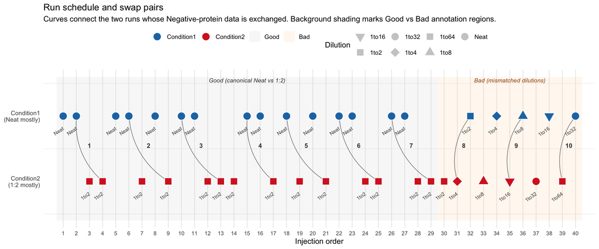

```r
ann_plot = annotation[Condition != "Blank"]
ann_plot[, Sample := str_extract(R.FileName, "(Neat|1to[0-9]+)")]
ann_plot[, y := fifelse(Condition == "Condition1", 2, 1)]

# Build pair-segment data: one row per pair, with start/end coordinates
pairs_dt = ann_plot[!is.na(Pair),
                     .(R.FileName, Order, y, Condition, Pair)]
pair_segs = merge(
  pairs_dt[Condition == "Condition1", .(Pair, x1 = Order, y1 = y)],
  pairs_dt[Condition == "Condition2", .(Pair, x2 = Order, y2 = y)],
  by = "Pair"
)

# Shade Good vs Bad regions (Good = Order 1-29, Bad = Order 30-40)
good_max = ann_plot[Label == "Good", max(Order)]
bad_max  = ann_plot[Label == "Bad",  max(Order)]
region = data.table(
  xmin  = c(0.5, good_max + 0.5),
  xmax  = c(good_max + 0.5, bad_max + 0.5),
  Label = c("Good", "Bad")
)

ggplot(ann_plot, aes(x = Order, y = y)) +
  geom_rect(data = region, inherit.aes = FALSE,
            aes(xmin = xmin, xmax = xmax, ymin = 0.4, ymax = 2.6,
                fill = Label), alpha = 0.10) +
  scale_fill_manual(values = c("Good" = "grey70", "Bad" = "#fdb863",
                                "Condition1" = "#1f77b4",
                                "Condition2" = "#d62728"),
                    breaks = c("Condition1", "Condition2", "Good", "Bad")) +
  # arcs connecting paired runs
  geom_curve(data = pair_segs,
             aes(x = x1, y = y1, xend = x2, yend = y2),
             curvature = 0.25, colour = "grey55", linewidth = 0.4,
             inherit.aes = FALSE) +
  # one point per run; fill = Condition; shape = Dilution
  geom_point(aes(fill = Condition, shape = Sample),
             size = 5, colour = "white", stroke = 0.6) +
  scale_shape_manual(values = c("Neat"  = 21, "1to2"  = 22, "1to4" = 23,
                                 "1to8"  = 24, "1to16" = 25, "1to32" = 21,
                                 "1to64" = 22)) +
  geom_text(data = pair_segs,
            aes(x = (x1 + x2) / 2, y = (y1 + y2) / 2 + 0.05,
                label = Pair),
            size = 3.2, fontface = "bold", colour = "grey25",
            inherit.aes = FALSE) +
  geom_text(aes(label = Sample, y = y - 0.18),
            size = 2.6, colour = "grey30", angle = 35, hjust = 1) +
  # Good/Bad strip header above plot
  annotate("text", x = good_max / 2 + 0.5, y = 2.55,
           label = "Good (canonical Neat vs 1:2)",
           size = 3, fontface = "italic", colour = "grey25") +
  annotate("text", x = (good_max + bad_max) / 2 + 0.5, y = 2.55,
           label = "Bad (mismatched dilutions)",
           size = 3, fontface = "italic", colour = "#a3550e") +
  scale_x_continuous(breaks = seq(1, 40, by = 1),
                      minor_breaks = NULL, expand = expansion(add = 1)) +
  scale_y_continuous(breaks = c(1, 2),
                      labels = c("Condition2\n(1:2 mostly)",
                                 "Condition1\n(Neat mostly)"),
                      limits = c(0.4, 2.6)) +
  labs(title = "Run schedule and swap pairs",
       subtitle = "Curves connect the two runs whose Negative-protein data is exchanged. Background shading marks Good vs Bad annotation regions.",
       x = "Injection order", y = NULL, fill = NULL, shape = "Dilution") +
  guides(fill = guide_legend(override.aes = list(shape = 21)),
         shape = guide_legend(override.aes = list(fill = "grey80"))) +
  theme(panel.grid.major.y = element_blank(),
        panel.grid.minor.x = element_blank(),
        legend.position = "top",
        axis.text.x = element_text(size = 8))
```

50 % of Cond1 runs (10 of 20) and 50 % of Cond2 runs (10 of 20) are paired; the other 50 % stay unpaired. That partial-swap is what produces the null — see `CSF_swap_design.md` §4.

# 2. Apply the swap to the protein-level data

We use the post-summarization swap helper here (results are equivalent to pre-summarization for this dataset; see §7 of the design doc). Positive proteins are untouched; Negative proteins have their `(originalRUN, GROUP)` re-attached via the alternating run flip.

```r
true_pos = swap_list[Label == "Positive", Protein]
true_neg = swap_list[Label == "Negative", Protein]

prot_before = copy(prot)
prot_before[, state := "before swap"]

prot_after = swap_condition_labels(prot, true_pos, true_neg) |> as.data.table()
prot_after[, state := "after swap"]

prot_all = rbindlist(list(prot_before, prot_after), use.names = TRUE, fill = TRUE)
prot_all[, class := fifelse(Protein %in% true_pos, "Positive", "Negative")]
prot_all[, state := factor(state, levels = c("before swap", "after swap"))]
```

# 3. Heatmap after the swap (Good runs only)

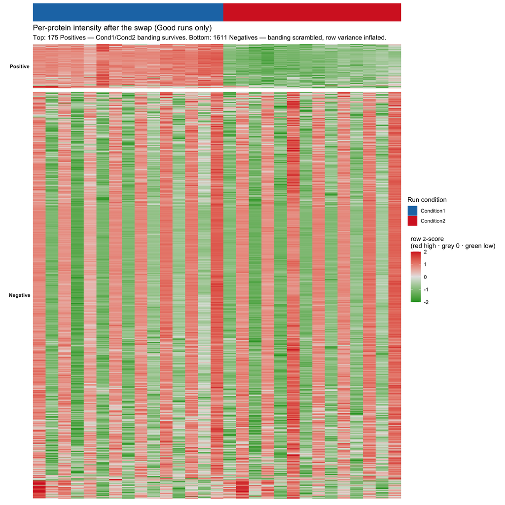

```r
good_runs  = annotation[Label == "Good", R.FileName]
good_order = annotation[Label == "Good"][order(Condition, Order),
                                          .(Run = R.FileName, Condition, Order)]

# For visualisation we need the run-swap (msqrob2-style): physically move
# Negative-protein intensities between paired runs. The post-dataProcess
# helper used in §2 only relabels GROUP and leaves per-run intensities
# unchanged — invisible in a heatmap plotted by originalRUN.
pair_map = annotation[!is.na(Pair),
                       .(Run = R.FileName, Pair, Condition)]
pair_lookup = merge(
  pair_map[Condition == "Condition1", .(Pair, Run1 = Run)],
  pair_map[Condition == "Condition2", .(Pair, Run2 = Run)],
  by = "Pair"
)
partner_map = c(setNames(pair_lookup$Run2, pair_lookup$Run1),
                setNames(pair_lookup$Run1, pair_lookup$Run2))

prot_runswap = copy(prot)
# Coerce factor columns to character so map lookups use labels, not factor
# integer codes. (Indexing a named vector with a factor returns the wrong
# elements — silent and easy to miss.)
prot_runswap[, originalRUN := as.character(originalRUN)]
prot_runswap[, Protein     := as.character(Protein)]

prot_runswap[Protein %in% true_neg & originalRUN %in% names(partner_map),
             originalRUN := unname(partner_map[originalRUN])]
prot_runswap[, class := fifelse(Protein %in% true_pos, "Positive",
                         fifelse(Protein %in% true_neg, "Negative", NA_character_))]

# Keep only the labeled proteins (the swap list defines the benchmark scope)
# and only the Good runs. Show ALL of them.
prot_g = prot_runswap[!is.na(class) & originalRUN %in% good_runs]

# Row z-score per protein, clipped for colour stability
prot_g[, z := scale(LogIntensities)[, 1], by = Protein]
prot_g[, z := pmax(pmin(z, 2), -2)]

# Cluster rows within each class for readability
make_row_order = function(dat) {
  m    = dcast(dat, Protein ~ originalRUN, value.var = "z")
  pids = m$Protein
  mat  = as.matrix(m[, -1, with = FALSE])
  mat[is.na(mat)] = 0
  ord  = if (nrow(mat) > 1) hclust(dist(mat))$order else 1
  pids[ord]
}
pos_keep = unique(prot_g[class == "Positive", Protein])
neg_keep = unique(prot_g[class == "Negative", Protein])
pos_ord  = make_row_order(prot_g[class == "Positive"])
neg_ord  = make_row_order(prot_g[class == "Negative"])

# Top facet = Positives, Bottom facet = Negatives
prot_g[, Protein := factor(Protein, levels = c(pos_ord, neg_ord))]
prot_g[, originalRUN := factor(originalRUN, levels = good_order$Run)]
prot_g[, class := factor(class, levels = c("Positive", "Negative"))]

# Column-condition strip (the legend the user asked for)
col_strip = good_order[, .(originalRUN = factor(Run, levels = good_order$Run),
                             Condition)]
p_strip = ggplot(col_strip,
                  aes(x = originalRUN, y = 1, fill = Condition)) +
  geom_tile() +
  scale_fill_manual(values = c("Condition1" = "#1f77b4",
                                "Condition2" = "#d62728"),
                    name = "Run condition") +
  scale_x_discrete(expand = c(0, 0)) +
  scale_y_continuous(expand = c(0, 0)) +
  labs(x = NULL, y = NULL) +
  theme_void() +
  theme(legend.position = "top",
        plot.margin = margin(t = 0, r = 0, b = 0, l = 0))

# Main heatmap (after swap only)
n_pos = length(pos_keep); n_neg = length(neg_keep)
p_heat = ggplot(prot_g,
                 aes(x = originalRUN, y = Protein, fill = z)) +
  geom_tile() +
  facet_grid(class ~ ., scales = "free_y", space = "free_y", switch = "y") +
  scale_fill_gradient2(low = "#2ca02c", mid = "grey90", high = "#d62728",
                       midpoint = 0, limits = c(-2, 2),
                       name = "row z-score\n(red high · grey 0 · green low)") +
  scale_x_discrete(expand = c(0, 0)) +
  labs(title = "Per-protein intensity after the swap (Good runs only)",
       subtitle = sprintf(
         "Top: %d Positives — Cond1/Cond2 banding survives. Bottom: %d Negatives — banding scrambled, row variance inflated.",
         length(pos_keep), length(neg_keep)),
       x = NULL, y = NULL) +
  theme(axis.text.x = element_blank(),
        axis.ticks.x = element_blank(),
        axis.text.y = element_blank(),
        axis.ticks.y = element_blank(),
        strip.text.y.left = element_text(angle = 0, face = "bold"),
        legend.position = "right",
        panel.spacing.y = unit(0.4, "lines"))

p_strip / p_heat + plot_layout(heights = c(0.04, 1), guides = "collect") &
  theme(legend.position = "right")
```

**What to see:**

- **Top facet (Positives, 10 %).** Clear vertical band: Cond1 columns (left) are systematically high (red), Cond2 columns (right) systematically low (green). The dilution signal is intact because Positives were not swapped.
- **Bottom facet (Negatives, 90 %).** The banding has collapsed — within each condition, columns carry a mixture of red and green cells with no consistent left/right difference. The mean DE has been erased, and the per-row colour spread is visibly larger — the variance inflation derived in §5 of the design doc.

# 4. Per-protein effect size and within-condition variance

Per-protein mean difference and pooled within-condition SD, computed on **Good runs only** (`Label == "Good"`, Order 1-29). The Bad runs span 1:4 — 1:64 dilutions and would inject extra heterogeneity into the SD estimate that is unrelated to the σ²+0.25 prediction.

```r
prot_good = prot_all[originalRUN %in% good_runs]

stats = prot_good[, .(mean_log = mean(LogIntensities, na.rm = TRUE),
                       sd_log   = sd(LogIntensities,  na.rm = TRUE),
                       n        = .N),
                   by = .(Protein, GROUP, state, class)]

wide = dcast(stats, Protein + state + class ~ GROUP,
             value.var = c("mean_log", "sd_log", "n"))

wide[, mean_diff := mean_log_Condition1 - mean_log_Condition2]
wide[, sd_pool   := sqrt(((n_Condition1 - 1) * sd_log_Condition1^2 +
                           (n_Condition2 - 1) * sd_log_Condition2^2) /
                          pmax(n_Condition1 + n_Condition2 - 2, 1))]
```

## 4.1 Effect size (mean Cond1 − mean Cond2)

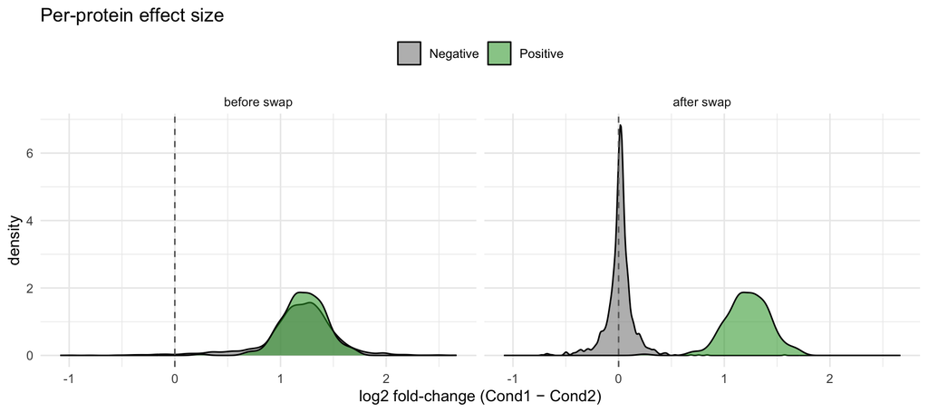

```r
ggplot(wide[is.finite(mean_diff)],
        aes(x = mean_diff, fill = class)) +
  geom_density(alpha = 0.55) +
  geom_vline(xintercept = 0, linetype = 2, colour = "grey40") +
  facet_wrap(~ state) +
  scale_fill_manual(values = c("Positive" = "#2ca02c",
                                "Negative" = "#7f7f7f")) +
  labs(title = "Per-protein effect size",
       x = "log2 fold-change (Cond1 − Cond2)", y = "density", fill = NULL) +
  theme(legend.position = "top")
```

Before the swap, **both** classes are centred on ~1 log2 (the dilution effect). After the swap, Negatives collapse to 0 while Positives stay at 1 — the manufactured contrast.

## 4.2 Within-condition standard deviation

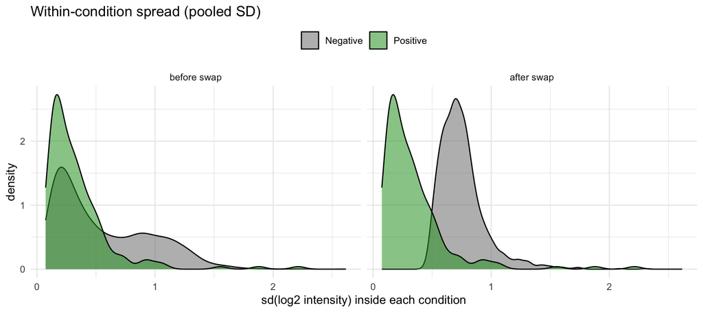

```r
ggplot(wide[is.finite(sd_pool)],
        aes(x = sd_pool, fill = class)) +
  geom_density(alpha = 0.55) +
  facet_wrap(~ state) +
  scale_fill_manual(values = c("Positive" = "#2ca02c",
                                "Negative" = "#7f7f7f")) +
  labs(title = "Within-condition spread (pooled SD)",
       x = "sd(log2 intensity) inside each condition", y = "density",
       fill = NULL) +
  theme(legend.position = "top")
```

This asymmetry is what biases empirical-Bayes variance moderation against methods like limma and DEqMS: the prior is fit on a 90/10 mixture and ends up biased toward the inflated Negative variance, which then over-shrinks Positive variance estimates upward and depresses both TPR and PPV.

## 4.3 Direct view of the moderation problem

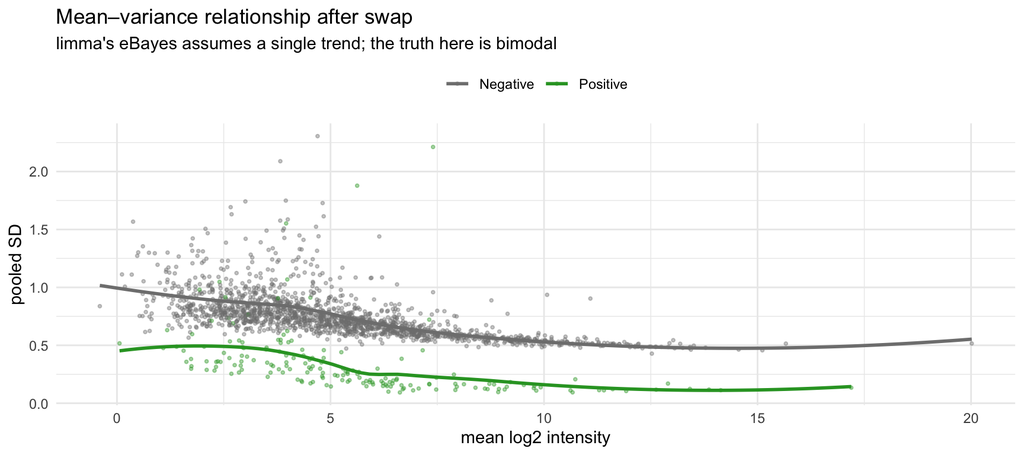

```r
mv = wide[is.finite(sd_pool) & state == "after swap"]
mv[, mean_intensity := 0.5 * (mean_log_Condition1 + mean_log_Condition2)]

ggplot(mv, aes(x = mean_intensity, y = sd_pool, colour = class)) +
  geom_point(alpha = 0.4, size = 0.7) +
  geom_smooth(se = FALSE, method = "loess") +
  scale_colour_manual(values = c("Positive" = "#2ca02c",
                                  "Negative" = "#7f7f7f")) +
  labs(title = "Mean–variance relationship after swap",
       subtitle = "limma's eBayes assumes a single trend; the truth here is bimodal",
       x = "mean log2 intensity", y = "pooled SD", colour = NULL) +
  theme(legend.position = "top")
```

Two roughly parallel mean-variance trends, one per class. Variance moderation collapses these into a single trend, biasing each class’s moderated variance toward the wrong target.

# 5. Take-aways